# Covid-19 effect on Liver Cancer Prediction (using R)

Oghenekeno Eribewe

2023-01-25

##### Loading required libraries

All necessary libraries for whatever manipulation that may be reqired is loaded

#### Brief overview of the data set

Loading the data set gotten from https://www.kaggle.com/datasets/fedesoriano/covid19-effect-on-liver-cancer-prediction-dataset with strings loaded as factors and header set to true as the data comes with headers.

```r
df = read.csv("covid-liver.csv", header = T, stringsAsFactors = T)
```

Next, we take a brief view and stats of the data to analyse the missing values and proceed with what ever solution we can come up with to sort those missing values.

```r
#View(df)
head(df, 5)
```

```
##   Cancer        Year Month Bleed Mode_Presentation Age Gender Etiology
## 1      Y Prepandemic     1     N      Surveillance  68      M    NAFLD
## 2      Y Prepandemic     1     N      Surveillance  70      M     ARLD
## 3      Y Prepandemic     1     N      Surveillance  64      M     ARLD
## 4      Y Prepandemic     1     N        Incidental  73      M     ARLD
## 5      Y Prepandemic     1     N        Incidental  66      F     ARLD
##   Cirrhosis Size HCC_TNM_Stage HCC_BCLC_Stage ICC_TNM_Stage  Treatment_grps
## 1         Y   22            II              A          <NA>        Ablation
## 2         Y   40             I              D          <NA> Supportive care
## 3         Y   52            IV              B          <NA>         Medical
## 4         Y   80            IV              C          <NA> Supportive care
## 5         Y   60             I              0          <NA> Supportive care
##   Survival_fromMDM Alive_Dead Type_of_incidental_finding Surveillance_programme
## 1            32.73      Alive                       <NA>                      Y
## 2             3.03       Dead                       <NA>                      Y
```

[output cut: 27 more lines]

```r
summary(df)
```

```
##  Cancer           Year         Month         Bleed        Mode_Presentation
##  N:140   Pandemic   :184   Min.   : 1.000   N   :304   Incidental  :145
##  Y:310   Prepandemic:266   1st Qu.: 4.000   Y   :  6   Surveillance:104
##                            Median : 7.000   NA's:140   Symptomatic :201
##                            Mean   : 6.758
##                            3rd Qu.:10.000
##                            Max.   :12.000
##
##       Age        Gender                Etiology   Cirrhosis       Size
##  Min.   :27.00   F:115   NAFLD             :120   N   : 96   Min.   : 10.00
##  1st Qu.:65.00   M:335   ARLD              : 95   Y   :215   1st Qu.: 24.00
##  Median :72.00           No established CLD: 38   NA's:139   Median : 40.00
##  Mean   :70.37           HCV               : 24              Mean   : 53.35
##  3rd Qu.:78.00           HH                : 15              3rd Qu.: 70.50
##  Max.   :96.00           (Other)           : 19              Max.   :220.00
##                          NA's              :139              NA's   :50
##    HCC_TNM_Stage HCC_BCLC_Stage ICC_TNM_Stage         Treatment_grps
##  I        :127   0   :  2       I   :  2      Supportive care:236
##  II       : 58   A   : 65       II  : 22      TACE           : 62
##  IIIA+IIIB: 86   B   : 25       III : 20      Medical        : 51
##  IV       : 40   C   :152       IV  : 95      Ablation       : 40
##  NA's     :139   D   : 67       NA's:311      Resection      : 30
##                  NA's:139                     (Other)        : 29
##                                               NA's           :  2
##  Survival_fromMDM Alive_Dead  Type_of_incidental_finding
##  Min.   :-0.030   Alive:186   Primary care\x97acute    :  5
##  1st Qu.: 4.032   Dead :264   Secondary care\x97routine: 23
##  Median :10.785               Primary care\x97routine  : 30
##  Mean   :12.697               Secondary care\x97acute  : 66
##  3rd Qu.:21.282               NA's                     :326
##  Max.   :32.770
##
##  Surveillance_programme Surveillance_effectiveness
##  N   :190               Consistent  : 78
##  Y   :121               Inconsistent: 21
##  NA's:139               Missed      : 18
##                         NA's        :333
##
##
##
```

[output cut: 17 more lines]

```
##  Min.   :-0.870                     N   :172
##  1st Qu.: 0.715                     Y   :273
##  Median : 1.370                     NA's:  5
##  Mean   : 1.501
##  3rd Qu.: 1.715
##  Max.   :11.900
##  NA's   :343
##  Months_from_last_surveillance
##  Min.   : 0.330
##  1st Qu.: 5.567
##  Median : 6.300
##  Mean   :10.650
##  3rd Qu.:10.600
##  Max.   :82.433
##  NA's   :338
```

It is observed that there are quite a number of fields with missing values, so we need to visualize these fields to observe the levels of these missing values in the different fields.

```r
# checking the sum of NA's in all columns
# sapply(covidLiver, anyNA)
df.Na = colSums(is.na(df))
print(df.Na)
```

```
##                             Cancer                               Year
##                                  0                                  0
##                              Month                              Bleed
##                                  0                                140
##                  Mode_Presentation                                Age
##                                  0                                  0
##                             Gender                           Etiology
##                                  0                                139
##                          Cirrhosis                               Size
##                                139                                 50
##                      HCC_TNM_Stage                     HCC_BCLC_Stage
##                                139                                139
##                      ICC_TNM_Stage                     Treatment_grps
##                                311                                  2
##                   Survival_fromMDM                         Alive_Dead
##                                  0                                  0
##         Type_of_incidental_finding             Surveillance_programme
##                                326                                139
##         Surveillance_effectiveness     Mode_of_surveillance_detection
##                                333                                352
##              Time_diagnosis_1st_Tx    Date_incident_surveillance_scan
##                                292                                417
##                                 PS             Time_MDM_1st_treatment
##                                  2                                288
## Time_decisiontotreat_1st_treatment               Prev_known_cirrhosis
##                                343                                  5
##      Months_from_last_surveillance
##                                338
```

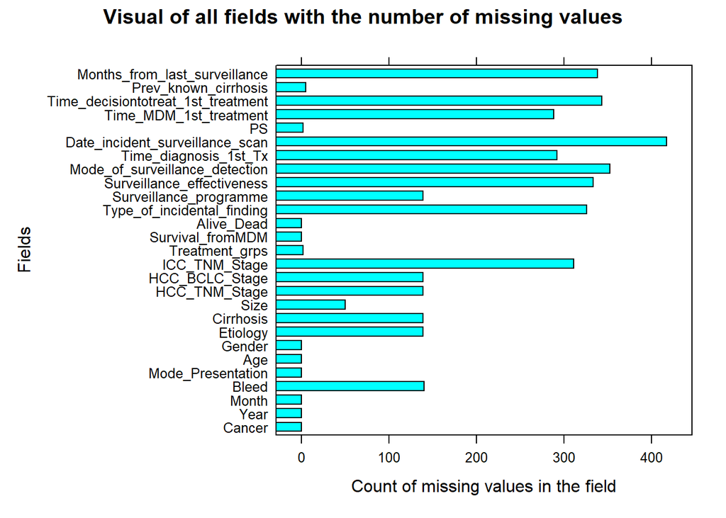

```r
# visualizing the number of columns with the quantity of  missing values
barchart(df.Na, xlab = "Count of missing values in the field", ylab = "Fields", main = "Visual of all fields with the number of missing values")
```

Quite a number of the fields have missing values consisting of more than 50% of the field and there is no way we can predict those missing values as there is not enough remaining data in the fields to make such prediction/assumption. Hence, there is need to remove these fields.

```r
# removing the columns using their field numbers
df[,c(13,17,19,20,21,22,24,25,27)] = NULL
summary(df)
```

```
##  Cancer           Year         Month         Bleed        Mode_Presentation
##  N:140   Pandemic   :184   Min.   : 1.000   N   :304   Incidental  :145
##  Y:310   Prepandemic:266   1st Qu.: 4.000   Y   :  6   Surveillance:104
##                            Median : 7.000   NA's:140   Symptomatic :201
##                            Mean   : 6.758
##                            3rd Qu.:10.000
##                            Max.   :12.000
##
##       Age        Gender                Etiology   Cirrhosis       Size
##  Min.   :27.00   F:115   NAFLD             :120   N   : 96   Min.   : 10.00
##  1st Qu.:65.00   M:335   ARLD              : 95   Y   :215   1st Qu.: 24.00
##  Median :72.00           No established CLD: 38   NA's:139   Median : 40.00
##  Mean   :70.37           HCV               : 24              Mean   : 53.35
##  3rd Qu.:78.00           HH                : 15              3rd Qu.: 70.50
##  Max.   :96.00           (Other)           : 19              Max.   :220.00
##                          NA's              :139              NA's   :50
##    HCC_TNM_Stage HCC_BCLC_Stage         Treatment_grps Survival_fromMDM
##  I        :127   0   :  2       Supportive care:236    Min.   :-0.030
##  II       : 58   A   : 65       TACE           : 62    1st Qu.: 4.032
##  IIIA+IIIB: 86   B   : 25       Medical        : 51    Median :10.785
##  IV       : 40   C   :152       Ablation       : 40    Mean   :12.697
##  NA's     :139   D   : 67       Resection      : 30    3rd Qu.:21.282
##                  NA's:139       (Other)        : 29    Max.   :32.770
##                                 NA's           :  2
##  Alive_Dead  Surveillance_programme       PS        Prev_known_cirrhosis
##  Alive:186   N   :190               Min.   :0.000   N   :172
##  Dead :264   Y   :121               1st Qu.:0.000   Y   :273
##              NA's:139               Median :1.000   NA's:  5
##                                     Mean   :1.225
##                                     3rd Qu.:2.000
##                                     Max.   :4.000
##                                     NA's   :2
```

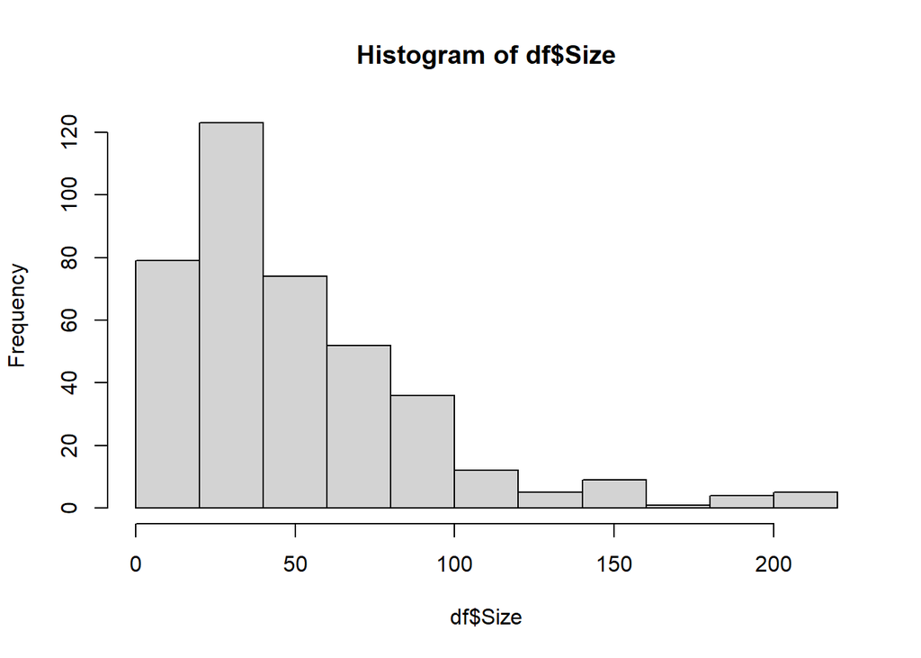

```r
# quick visual of the distribution of the values in the field
hist(x = df$Size, freq = TRUE)
```

The distribution is positively skewed, and so the best option would be to impute the median as it would be a more representative value than the mean.

```r
df$Size = impute((df$Size), median)
summary(df$Size)
```

```
##
##  50 values imputed to 40
```

```
##    Min. 1st Qu.  Median    Mean 3rd Qu.    Max.
##   10.00   25.00   40.00   51.87   66.50  220.00
```

Next, we impute the mode for the treatment_grps as it only has 2 missing values and we do not want to drop the rows

```r
# next we handle the field treatment_grps
df$Treatment_grps = impute((df$Treatment_grps), mode)
summary(df$Treatment_grps)
```

```
##
##  2 values imputed to Supportive care
```

```
##        Ablation         Medical            OLTx       Resection            SIRT
##              40              51               7              30              22
## Supportive care            TACE
##             238              62
```

Next, we visualise the distribution for the PS as it only has 2 missing values

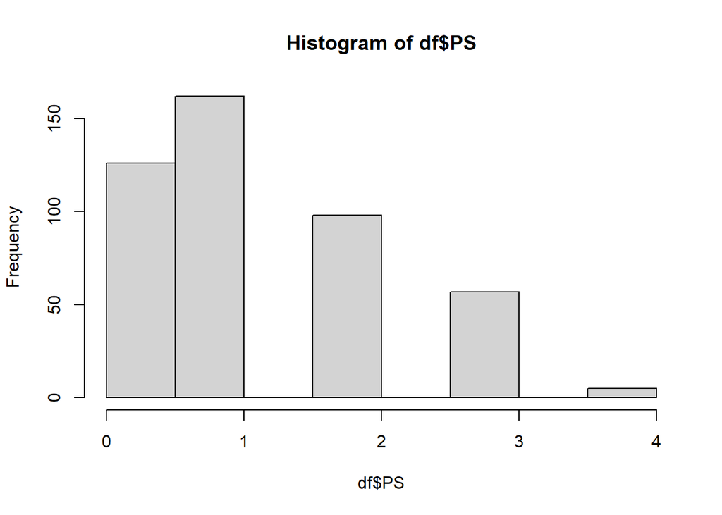

```r
# quick visual of the distribution of the values in the field
hist(x = df$PS)
```

```r
# the median seems ideal to impute as the distribution is awkwardly skewed
df$PS = impute((df$PS), median)
summary(df$PS)
```

```
##
##  2 values imputed to 1
```

```
##    Min. 1st Qu.  Median    Mean 3rd Qu.    Max.
##   0.000   0.000   1.000   1.224   2.000   4.000
```

```r
summary(df)
```

```
##
##  50 values imputed to 40
##
##
##  2 values imputed to Supportive care
##
##
##  2 values imputed to 1
```

```
##  Cancer           Year         Month         Bleed        Mode_Presentation
##  N:140   Pandemic   :184   Min.   : 1.000   N   :304   Incidental  :145
##  Y:310   Prepandemic:266   1st Qu.: 4.000   Y   :  6   Surveillance:104
##                            Median : 7.000   NA's:140   Symptomatic :201
##                            Mean   : 6.758
##                            3rd Qu.:10.000
##                            Max.   :12.000
##
##       Age        Gender                Etiology   Cirrhosis       Size
##  Min.   :27.00   F:115   NAFLD             :120   N   : 96   Min.   : 10.00
##  1st Qu.:65.00   M:335   ARLD              : 95   Y   :215   1st Qu.: 25.00
##  Median :72.00           No established CLD: 38   NA's:139   Median : 40.00
##  Mean   :70.37           HCV               : 24              Mean   : 51.87
##  3rd Qu.:78.00           HH                : 15              3rd Qu.: 66.50
##  Max.   :96.00           (Other)           : 19              Max.   :220.00
##                          NA's              :139
##    HCC_TNM_Stage HCC_BCLC_Stage         Treatment_grps Survival_fromMDM
##  I        :127   0   :  2       Ablation       : 40    Min.   :-0.030
##  II       : 58   A   : 65       Medical        : 51    1st Qu.: 4.032
##  IIIA+IIIB: 86   B   : 25       OLTx           :  7    Median :10.785
##  IV       : 40   C   :152       Resection      : 30    Mean   :12.697
##  NA's     :139   D   : 67       SIRT           : 22    3rd Qu.:21.282
##                  NA's:139       Supportive care:238    Max.   :32.770
##                                 TACE           : 62
##  Alive_Dead  Surveillance_programme       PS        Prev_known_cirrhosis
##  Alive:186   N   :190               Min.   :0.000   N   :172
##  Dead :264   Y   :121               1st Qu.:0.000   Y   :273
##              NA's:139               Median :1.000   NA's:  5
##                                     Mean   :1.224
##                                     3rd Qu.:2.000
##                                     Max.   :4.000
##
```

Next, we impute the mode for the Prev_known_cirrhosis as it only has 5 missing values and we do not want to drop the rows

```r
# next we handle the field Prev_known_cirrhosis
df$Prev_known_cirrhosis = impute((df$Prev_known_cirrhosis), mode)
summary(df$Prev_known_cirrhosis)
```

```
##
##  5 values imputed to Y
```

```
##   N   Y
## 172 278
```

From the mice library, we use the random forest mice function to predict the missing categorical values.

```r
imputed_data = mice(df, m=5, method = "rf")
summary(imputed_data)
```

```
## Class: mids
## Number of multiple imputations:  5
## Imputation methods:
##                 Cancer                   Year                  Month
##                     ""                     ""                     ""
##                  Bleed      Mode_Presentation                    Age
##                   "rf"                     ""                     ""
##                 Gender               Etiology              Cirrhosis
##                     ""                   "rf"                   "rf"
##                   Size          HCC_TNM_Stage         HCC_BCLC_Stage
##                     ""                   "rf"                   "rf"
##         Treatment_grps       Survival_fromMDM             Alive_Dead
##                     ""                     ""                     ""
## Surveillance_programme                     PS   Prev_known_cirrhosis
##                   "rf"                     ""                     ""
## PredictorMatrix:
##                   Cancer Year Month Bleed Mode_Presentation Age Gender Etiology
## Cancer                 0    1     1     1                 1   1      1        1
## Year                   1    0     1     1                 1   1      1        1
## Month                  1    1     0     1                 1   1      1        1
## Bleed                  1    1     1     0                 1   1      1        1
## Mode_Presentation      1    1     1     1                 0   1      1        1
## Age                    1    1     1     1                 1   0      1        1
##                   Cirrhosis Size HCC_TNM_Stage HCC_BCLC_Stage Treatment_grps
## Cancer                    1    1             1              1              1
## Year                      1    1             1              1              1
## Month                     1    1             1              1              1
## Bleed                     1    1             1              1              1
## Mode_Presentation         1    1             1              1              1
## Age                       1    1             1              1              1
##                   Survival_fromMDM Alive_Dead Surveillance_programme PS
## Cancer                           1          1                      1  1
## Year                             1          1                      1  1
## Month                            1          1                      1  1
## Bleed                            1          1                      1  1
## Mode_Presentation                1          1                      1  1
## Age                              1          1                      1  1
##                   Prev_known_cirrhosis
## Cancer                               1
## Year                                 1
## Month                                1
## Bleed                                1
## Mode_Presentation                    1
## Age                                  1
## Number of logged events:  25
##   it im   dep meth     out
## 1  1  1 Bleed   rf CancerY
## 2  1  2 Bleed   rf CancerY
## 3  1  3 Bleed   rf CancerY
## 4  1  4 Bleed   rf CancerY
## 5  1  5 Bleed   rf CancerY
## 6  2  1 Bleed   rf CancerY
```

So we use the 5th cycle out of the 5 cycles of predictions made.

```r
cleaned_df = complete(imputed_data, 5)
summary(cleaned_df)
```

```
##
##  2 values imputed to Supportive care
##
##
##  5 values imputed to Y
```

```
##  Cancer           Year         Month        Bleed      Mode_Presentation
##  N:140   Pandemic   :184   Min.   : 1.000   N:444   Incidental  :145
##  Y:310   Prepandemic:266   1st Qu.: 4.000   Y:  6   Surveillance:104
##                            Median : 7.000           Symptomatic :201
##                            Mean   : 6.758
##                            3rd Qu.:10.000
##                            Max.   :12.000
##
##       Age        Gender                Etiology   Cirrhosis      Size
##  Min.   :27.00   F:115   ARLD              :167   N:102     Min.   : 10.00
##  1st Qu.:65.00   M:335   NAFLD             :166   Y:348     1st Qu.: 25.00
##  Median :72.00           No established CLD: 41             Median : 40.00
##  Mean   :70.37           HCV               : 32             Mean   : 51.87
##  3rd Qu.:78.00           HH                : 20             3rd Qu.: 66.50
##  Max.   :96.00           PBC/AIH           : 17             Max.   :220.00
##                          (Other)           :  7
##    HCC_TNM_Stage HCC_BCLC_Stage         Treatment_grps Survival_fromMDM
##  I        :173   0:  2          Ablation       : 40    Min.   :-0.030
##  II       : 78   A: 93          Medical        : 51    1st Qu.: 4.032
##  IIIA+IIIB:138   B: 30          OLTx           :  7    Median :10.785
##  IV       : 61   C:230          Resection      : 30    Mean   :12.697
##                  D: 95          SIRT           : 22    3rd Qu.:21.282
##                                 Supportive care:238    Max.   :32.770
##                                 TACE           : 62
##  Alive_Dead  Surveillance_programme       PS        Prev_known_cirrhosis
##  Alive:186   N:294                  Min.   :0.000   N:172
##  Dead :264   Y:156                  1st Qu.:0.000   Y:278
##                                     Median :1.000
##                                     Mean   :1.224
##                                     3rd Qu.:2.000
##                                     Max.   :4.000
##
```

```r
df1 = cleaned_df

write.csv(df1, "clean-CovidLiver.csv", row.names = FALSE)
```

##### Feature Importance Check

```r
# feature selection
set.seed(123)
B.df = Boruta(Cancer~., data = cleaned_df, doTrace = 2)
```

[output not shown]

[output not shown]

[output not shown]

[output not shown]

[output not shown]

[output not shown]

[output not shown]

[output not shown]

[output not shown]

[output not shown]

[output not shown]

```
## After 11 iterations, +2.7 secs:
```

```
##  confirmed 10 attributes: Age, Alive_Dead, Cirrhosis, Etiology, Mode_Presentation and 5 more;
```

```
##  still have 7 attributes left.
```

[output not shown]

[output not shown]

[output not shown]

[output not shown]

[output not shown]

[output not shown]

[output not shown]

[output not shown]

[output not shown]

[output not shown]

[output not shown]

[output not shown]

[output not shown]

[output not shown]

```
## After 25 iterations, +6.1 secs:
```

```
##  rejected 1 attribute: Bleed;
```

```
##  still have 6 attributes left.
```

[output not shown]

[output not shown]

[output not shown]

[output not shown]

[output not shown]

[output not shown]

[output not shown]

[output not shown]

[output not shown]

[output not shown]

[output not shown]

[output not shown]

[output not shown]

[output not shown]

[output not shown]

[output not shown]

[output not shown]

```
## After 42 iterations, +9.4 secs:
```

```
##  confirmed 1 attribute: PS;
```

```
##  rejected 1 attribute: Month;
```

```
##  still have 4 attributes left.
```

[output not shown]

[output not shown]

[output not shown]

```
## After 45 iterations, +10 secs:
```

```
##  confirmed 1 attribute: HCC_BCLC_Stage;
```

```
##  still have 3 attributes left.
```

[output not shown]

[output not shown]

[output not shown]

[output not shown]

[output not shown]

[output not shown]

[output not shown]

[output not shown]

[output not shown]

[output not shown]

[output not shown]

[output not shown]

[output not shown]

```
## After 58 iterations, +13 secs:
```

```
##  rejected 1 attribute: Year;
```

```
##  still have 2 attributes left.
```

[output not shown]

[output not shown]

[output not shown]

[output not shown]

[output not shown]

[output not shown]

[output not shown]

[output not shown]

[output not shown]

[output not shown]

[output not shown]

[output not shown]

[output not shown]

[output not shown]

[output not shown]

[output not shown]

[output not shown]

```
## After 75 iterations, +16 secs:
```

```
##  confirmed 1 attribute: Gender;
```

```
##  still have 1 attribute left.
```

[output not shown]

[output not shown]

[output not shown]

[output not shown]

[output not shown]

[output not shown]

[output not shown]

[output not shown]

[output not shown]

[output not shown]

[output not shown]

[output not shown]

[output not shown]

[output not shown]

[output not shown]

[output not shown]

[output not shown]

[output not shown]

[output not shown]

[output not shown]

[output not shown]

[output not shown]

[output not shown]

[output not shown]

```r
# results summary
print(B.df)
```

```
## Boruta performed 99 iterations in 20.11405 secs.
##  13 attributes confirmed important: Age, Alive_Dead, Cirrhosis,
## Etiology, Gender and 8 more;
##  3 attributes confirmed unimportant: Bleed, Month, Year;
##  1 tentative attributes left: HCC_TNM_Stage;
```

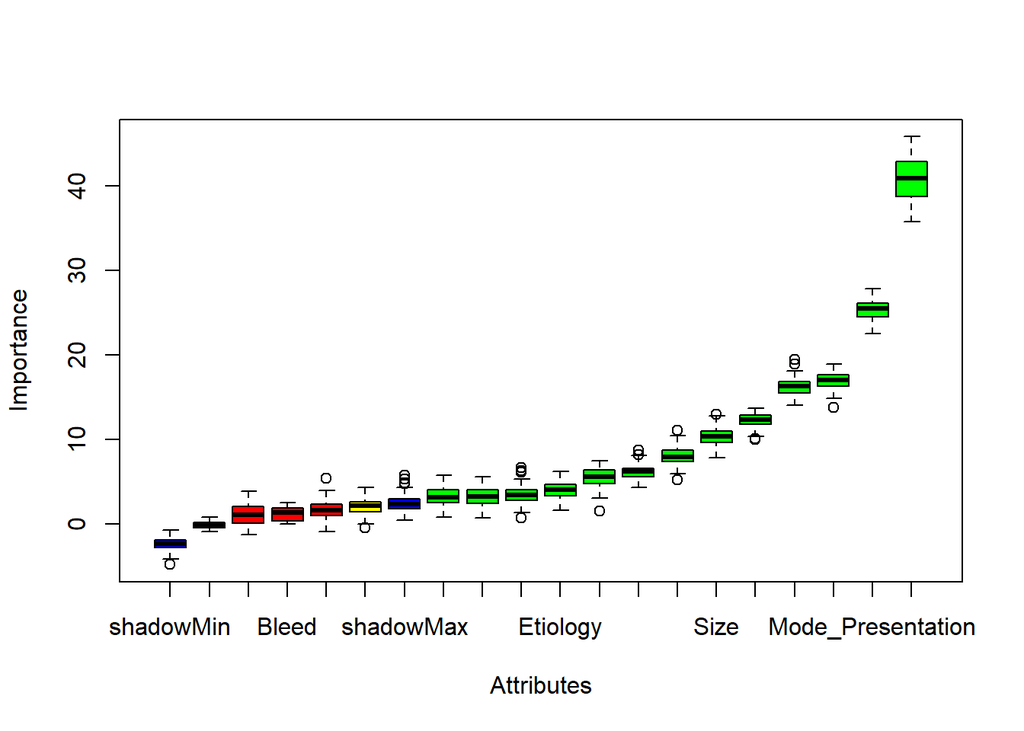

```r
# results plot
plot(B.df)
```

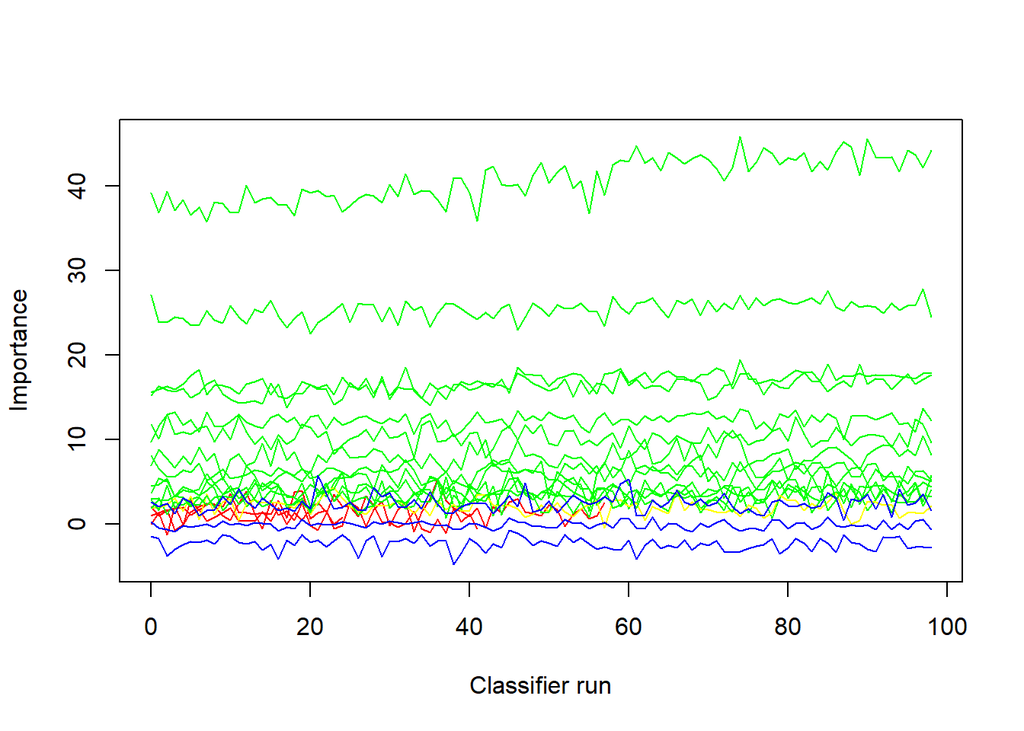

```r
plotImpHistory(B.df)
```

```r
# attributes statistics
attStats(B.df)
```

```
##                          meanImp medianImp      minImp    maxImp   normHits
## Year                    1.544891  1.553171 -0.90710837  5.368766 0.16161616
## Month                   1.041262  1.058125 -1.28065219  3.874413 0.10101010
## Bleed                   1.135604  1.298678 -0.06240825  2.511906 0.04040404
## Mode_Presentation      25.309141 25.438288 22.50217687 27.777478 1.00000000
## Age                     5.508309  5.569459  1.47633595  7.484672 0.94949495
## Gender                  3.206076  3.193830  0.69805739  5.537055 0.69696970
## Etiology                3.991205  4.051809  1.59096065  6.170641 0.88888889
## Cirrhosis              12.254516 12.345899 10.00836813 13.665747 1.00000000
## Size                   10.354128 10.318234  7.82776295 12.940316 1.00000000
## HCC_TNM_Stage           2.019572  2.089639 -0.47298597  4.314777 0.40404040
## HCC_BCLC_Stage          3.464619  3.416796  0.73585493  6.621433 0.79797980
## Treatment_grps         16.892637 17.022088 13.77998021 18.900254 1.00000000
## Survival_fromMDM        8.021990  7.894784  5.17695311 11.067888 1.00000000
## Alive_Dead              6.156757  6.170712  4.26364265  8.666494 0.98989899
## Surveillance_programme 16.169451 16.283813 14.02589575 19.418738 1.00000000
## PS                      3.173627  3.133597  0.82487871  5.767678 0.71717172
## Prev_known_cirrhosis   40.700004 40.819361 35.71865307 45.772965 1.00000000
##                         decision
## Year                    Rejected
## Month                   Rejected
## Bleed                   Rejected
## Mode_Presentation      Confirmed
## Age                    Confirmed
## Gender                 Confirmed
## Etiology               Confirmed
## Cirrhosis              Confirmed
## Size                   Confirmed
## HCC_TNM_Stage          Tentative
## HCC_BCLC_Stage         Confirmed
## Treatment_grps         Confirmed
## Survival_fromMDM       Confirmed
## Alive_Dead             Confirmed
## Surveillance_programme Confirmed
## PS                     Confirmed
## Prev_known_cirrhosis   Confirmed
```